# Copy of Graficos_bitcoin

Titulo1: Implementando gráficos para análise de criptomoedas

**Titulo2: Os 4 gráficos essenciais para análise de criptomoedas**

Titulo3: Introdução a visualização de criptomoedas em Python

1. Para começar, iniciaremos carregando as bibliotecas utilizadas para a obtenção dos dados e elaboração dos gráficos.

```python
#!pip install quandl
```

```python
#!pip install quandl
import os
import numpy as np
import pandas as pd
import pandas_datareader.data as pdr
import matplotlib.pyplot as plt
import seaborn as sn
import pickle
import quandl
from datetime import datetime
#caso seja preciso instale quandl
import plotly.offline as py
import plotly.graph_objs as go
import plotly.figure_factory as ff
py.init_notebook_mode(connected = True),0,
```

```
(None, 0)
```

O Quandl é um dos mais importante provedores de dados financeiros do mundo, tendo mais 400,000 mil usuários em todo globo, essa plataforma disponibiliza dados gratuitamente, indo de dados corporativos, perfil de profissionais contratados até dados de criptomoedas. Iremos utilizar sua biblioteca e, python para conseguir nossos dados. Agora definimos a função para baixar e armazenar os dados do Quandl

```python
def get_quandl_data(quandl_id):
    '''Baixa e armazena dados do Quandl'''
    cache_path = '{}.pkl'.format(quandl_id).replace('/','-')
    try:
        f = open(cache_path, 'rb')
        df = pickle.load(f)
        print('Loaded {} from cache'.format(quandl_id))
    except (OSError, IOError) as e:
        print('Downloading {} from Quandl'.format(quandl_id))
        df = quandl.get(quandl_id, returns='pandas')
        df.to_pickle(cache_path)
        print('Cached {} at {}'.format(quandl_id, cache_path))
    return df
```

No desenvolvimento de um programa, muitas vezes executamos varias vezes a mesma linha de código. Como nosso acesso aos dados de interesse é feito através de plataformas online, muitas vezes essas plataformas limitam o número de solicitações. Um número de solicitações excessivo pode sobrecarregar os servidores se realizado em larga escala. Essas plataformas tendem a punir os Ips(Endereço de rede) dos usuários abusivos, restringindo seu acesso. Para evitar tais consequências, iremos utilizar a função Pickle que previne o download do mesmo arquivo, quando executamos nosso programa repetidamente. A função "pickle" previne o download do mesmo arquivo, quando executamos nosso programa repetidamente.

1.2. Agora iremos obter os dados da casas de câmbio de criptomoedas KRAKEN, obtendo dados do histórico de preços do bitcoin. Na tabela temos as informações de data, preço de abertura, preço de fechamento, valores máximo e mínimo alcançados e seu volume. O acesso a esses dados do Quandl é limitado para o uso sem declaração de chave da API. Caso você tenha problemas por excesso de limite de tentativas crie uma conta do site https://www.quandl.com/tools/api , e poderá ter sua própria chave de API, que deve inserir na função [quandl.ApiConfig.api_key = 'SUACHAVEDAAPI']

```python
#dados da Kraken preço BTC
quandl.ApiConfig.api_key = 'tPmEL-xXeBNpx2qGgCMa'
btc_usd_price_kraken = get_quandl_data('BCHARTS/KRAKENUSD')
btc_usd_price_kraken.head()
```

```
Downloading BCHARTS/KRAKENUSD from Quandl
Cached BCHARTS/KRAKENUSD at BCHARTS-KRAKENUSD.pkl
```

| Date | Open | High | Low | Close | Volume (BTC) | Volume (Currency) | Weighted Price |
| --- | --- | --- | --- | --- | --- | --- | --- |
| 2014-01-07 | 874.67040 | 892.06753 | 810.00000 | 810.00000 | 15.622378 | 13151.472844 | 841.835522 |
| 2014-01-08 | 810.00000 | 899.84281 | 788.00000 | 824.98287 | 19.182756 | 16097.329584 | 839.156269 |
| 2014-01-09 | 825.56345 | 870.00000 | 807.42084 | 841.86934 | 8.158335 | 6784.249982 | 831.572913 |
| 2014-01-10 | 839.99000 | 857.34056 | 817.00000 | 857.33056 | 8.024510 | 6780.220188 | 844.938794 |
| 2014-01-11 | 858.20000 | 918.05471 | 857.16554 | 899.84105 | 18.748285 | 16698.566929 | 890.671709 |

1.3. Para realizar o gráfico de linhas utilizar a função "Scatter", definindo como eixo x as datas e como eixo y, os preços em dólares. Caso esteja utilizado o google colab, faz-se necessário o uso da função, “configure_plotly_browser_state”, que permite ao colab a disposição de gráficos interativos da biblioteca “plotly”. Isso ocorre por conta da falta de parâmetros pelo colab na leitura dos módulos javascript implementados no plotly. O uso dessa função, corrige essa demandas. Se você usa alguma outro ambiente, como o jupyter por exemplo, o uso dessa função não se faz necessária.

```python
# gráfico BTC USD

def configure_plotly_browser_state():
  import IPython
  display(IPython.core.display.HTML('''
        <script src = "/static/components/requirejs/require.js"></script>
        <script>
          requirejs.config({
            paths: {
              base: '/static/base',
              plotly: 'https://cdn.plot.ly/plotly-1.5.1.min.js?noext',
            },
          });
        </script>
        '''))
configure_plotly_browser_state()

btc_trace = go.Scatter(x = btc_usd_price_kraken.index,
                       y = btc_usd_price_kraken['Weighted Price'])
data = [btc_trace]

py.iplot(data)
```

[interactive chart not shown]

Dessa forma temos o gráfico de linhas da série temporal disposto de uma forma interativa, podendo selecionar, qualquer período de tempo que se queira visualizar. É interessante notar que no dia 21/09/2018, ocorreu uma queda repentina no preço do ativo. Isso ocorreu devido a uma sugestão da Financial Integrity Network(FIN), para o congresso dos Estados Unidos, de criação de uma nova agência reguladora, para regular somente criptomoedas. Isso fez com que a corretora na qual estamos obtendo os dados, encerrassem negociações, naquele dia.

1. Agora a partir dos dados do bitcoin já baixados, iremos implementar um gráfico candlestick. Como passo inicial iremos carregar os pacotes necessários

```python
import plotly.graph_objects as go
```

2.1. As informações das datas vêm anexadas nos dados como index, precisamos transformá-los em uma variável.

```python
btc_usd_price_kraken['Data'] = btc_usd_price_kraken.index.values
```

Para a implementação foi utilizada a função candlestick da biblioteca plotly, onde é necessário definir as variáveis de abertura, fechamento, mínimo e máximo, que são os componentes do candlestick.

```python
configure_plotly_browser_state()

py.init_notebook_mode(connected = False)

fig = go.Figure(data = [go.Candlestick(x = btc_usd_price_kraken['Data'],
    open = btc_usd_price_kraken['Open'], high = btc_usd_price_kraken['High'],
    low = btc_usd_price_kraken['Low'], close = btc_usd_price_kraken['Close'])
    ])

fig.update_layout(xaxis_rangeslider_visible = False)

py.iplot(fig)
```

[interactive chart not shown]

Como no gráfico de linhas, o gráfico é interativo e podemos selecionar qualquer janela de tempo disponível nos dados.

1. Para avaliar o comportamento da série temporal, iremos suavizar a serie através de médias móveis para distintos intervalos de dias.

3.1. Primeiro temos que obter os dados das criptomoedas de interresse.

```python
#Setting the end date to today
end = datetime.today()

#Start date set to one year back
start = datetime(end.year-1,end.month,end.day)
#using yahoo finance to grab cryptocurrency data

BTC = pdr.DataReader('BTC-USD','yahoo',start,end)
ETH = pdr.DataReader('ETH-USD','yahoo',start,end)
LTC = pdr.DataReader('LTC-USD','yahoo',start,end)
XRP = pdr.DataReader('XRP-USD','yahoo',start,end)
TRX = pdr.DataReader('TRX-USD','yahoo',start,end)
EOS = pdr.DataReader('EOS-USD','yahoo',start,end)
DASH = pdr.DataReader('DASH-USD','yahoo',start,end)
```

3.2. Agora definiremos os intervalos de tempo em 10, 20 e 50 dias, calcularemos uma nova série através de médias moveis, para cada intervalo de tempo, e, compara-los no mesmo gráfico.

```python
configure_plotly_browser_state()
ma_days = [10,20,50]
for ma in ma_days:
    column_name = "MA %s days" %(str(ma))
    BTC[column_name] = BTC["Adj Close"].rolling(window=ma,center=False).mean()


fig = go.Figure()

fig.add_trace(go.Scatter(x=BTC.index, y=BTC['Adj Close'],
                    mode='lines',
                    name='Original'))

fig.add_trace(go.Scatter(x=BTC.index, y=BTC['MA 10 days'],
                    mode='lines',
                    name='MA 10 days'))

fig.add_trace(go.Scatter(x=BTC.index, y=BTC['MA 20 days'],
                    mode='lines',
                    name='MA 20 days'))

fig.add_trace(go.Scatter(x=BTC.index, y=BTC['MA 50 days'],
                    mode='lines',
                    name='MA 50 days'))
```

[interactive chart not shown]

1. Agora iremos implementar um Heatmap para criptomoedas, para isso vamos calcular as correlações entre todas as moedas que solicitamos o acesso dos dados.

4.1. Primeiro iremos criar uma tabela, apenas com os preços de fechamento das criptomoedas.

```python
data={'BTC':BTC['Close'],'ETH':ETH['Close'], 'LTC':LTC['Close'],
      'XRP':XRP['Close'],'TRX':TRX['Close'],'EOS':EOS['Close'],
      'DASH':DASH['Close']}

df = pd.DataFrame(data)

df.head()
```

| Date | BTC | ETH | LTC | XRP | TRX | EOS | DASH |
| --- | --- | --- | --- | --- | --- | --- | --- |
| 2019-04-28 | 5247.352539 | 155.201996 | 67.960381 | 0.294289 | 0.022839 | 4.526187 | 108.108337 |
| 2019-04-29 | 5350.726562 | 162.166031 | 74.280876 | 0.309476 | 0.023971 | 4.827270 | 111.789932 |
| 2019-04-30 | 5402.697266 | 160.818344 | 73.657768 | 0.304696 | 0.023776 | 4.782023 | 117.194695 |
| 2019-05-01 | 5505.283691 | 162.122787 | 73.777176 | 0.303239 | 0.023652 | 4.788843 | 117.242584 |
| 2019-05-02 | 5768.289551 | 167.952408 | 79.326538 | 0.308222 | 0.024073 | 5.085449 | 121.098778 |

4.2. Agora Iremos calcular uma a matriz de correlação entre os preços de fechamento das moedas e implementar o Heatmap.

```
           BTC       ETH       LTC       XRP       TRX       EOS      DASH
BTC   1.000000  0.669673  0.598267  0.518801  0.471078  0.422867  0.481814
ETH   0.669673  1.000000  0.878395  0.852405  0.866727  0.845110  0.867675
LTC   0.598267  0.878395  1.000000  0.939102  0.948374  0.928957  0.908047
XRP   0.518801  0.852405  0.939102  1.000000  0.952422  0.934392  0.866426
TRX   0.471078  0.866727  0.948374  0.952422  1.000000  0.955060  0.912767
EOS   0.422867  0.845110  0.928957  0.934392  0.955060  1.000000  0.944774
DASH  0.481814  0.867675  0.908047  0.866426  0.912767  0.944774  1.000000
```

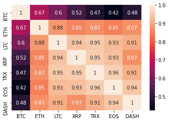

```python
corrMatrix = df.corr()

print (corrMatrix)

corrMatrix = df.corr()
sn.heatmap(corrMatrix, annot=True)
plt.show()
```

Conclusão. Nesse artigo tivemos uma introdução de como realizar análises gráficas básicas para os dados de criptomoedas, verificando seu comportamento como série temporal e a distribuição dos seus distintos preços, a análise da suavização da série através de médias móveis e a visualização da contaminação dos preços das criptomoedas entre si, através da matriz de correlação.

Referências:

https://blog.patricktriest.com/analyzing-cryptocurrencies-python/

https://plotly.com/python/candlestick-charts/

https://medium.com/@melvfnz/how-to-use-python-to-analyze-cryptocurrencies-c5b9601ee0bb

https://blog.kraken.com/post/2732/the-weekly-hash-september-2-6/